# Sluttfarten til en rullende kule i en kulebane

*Einar Midthun, Albert Strømhylden, Magnus Trandokken og Amund Wirstad*

# 1 Sammendrag

# 2 Introduksjon

Newton formulerte kraftlovene som i dag utgjør fundamentet i mekanikk. Lovene beskriver sammenhengen mellom kraft og akselerasjon, altså hvordan gjenstander beveger seg eller forblir i ro. Disse lovene, sammen med prinsippet om energibevaring og rullebetingelser, er det teoretiske grunnlaget som brukes i eksperimentet. Eksperimentet handler om målinger og numeriske utregninger av en kule i en krum rullebane. Ved hjelp av sporingsprogrammet Tracker og beregninger gjort i Python, gjennomføres eksperimentet med hensikt om å beregne sluttfarten og den endelige kinetiske energien, sammen med relevante mekaniske størrelser. Motivasjonen bak eksperimentet er å sammenligne de numeriske resultatene og faktiske målingene for den samme banen.

# 3 Teori

Teorien som nå presenteres vil relateres til et generelt scenario hvor en kule med uniform massefordelig ruller (uten å skli) langs en nedovergående bane med ujevn krumning. Banens krumningsradius er til enhver tid er mye større en kulens radius. Kulebanen kan utrykkes ved en funksjon $y(x)$. Det antas at kulen ruller fritt, og ikke sklir. Kulen har ingen starthastighet. Dette er for å begrense teorien til det som er relevant for rapporten.

### Første lov

Newtons første lov sier at dersom det ikke virker noen krefter på et legeme, vil det ligge i ro eller fortsette med konstant hastighet. Med andre ord må det en kraft til for å sette et legeme i bevegelse, og får å endre hastighet. Dette kalles også treghetsloven, fordi legemets treghet bestemmer legemets oppførsel når påvirket av krefter. (Grøn, 2021b). En kule har et treghetsmoment gitt ved

$$I = cMR^2 \tag{3.a}$$

der hvor $M$ er kulens masse, og $R$ er kulens radius. Kulens radius kan beskrives som avstanden mellom kulens massesenter og kontaktpunktet mellom kulen og underlaget. I en kule med uniform massefordeling er $c = \frac{2}{5}$. (Grøn, 2019)

### Andre lov

Newtons andre lov sier at et legeme som påvirkes av en eller flere krefter vil få en akselerasjon i den retingen kreftene virker. Dette kan utledes fra formelen $F = ma$, der $F$ summen av krefter som virker på legemet, $m$ massen til legemet og $a$ akselerasjonen. (Grøn, 2021b)

### Tredje lov

"Newtons tredje lov sier at når et legeme virker på et annet legeme med en kraft, vil det andre legemet virke tilbake på det første med en like stor kraft i motsatt retning." Det vil si at kraft og motkraft alltid er like store og i motsatt retning. (Grøn, 2021b)

### Bevaringslovene

Dersom et system ikke blir fratatt eller tilført masse eller energi, vil systemet være bevart. Systemet vil ikke forandre total energi eller masse. Energien kan forandre form som f.eks. fra potensiell energi og bevegelsesenergi, til varmeenergi (Grøn, 2019). En Kule som ruller langs en nedovergående bane vil til enhver tid ha potensiell energi lik $mgh$, der $g$ er tilnærmet lik $9.81m/s^2$. Kulen vil og ha en bevegelsesenergi som konsekvens av fart($v$) lik $\frac{mv^2}{2}$. Siden kulen også roterer når den ferdes langs banen blir den totale kinetiske energien summen av bevegelsesenergi og rotasjonsenergi lik $\frac{I⋅\omega^2}{2}$, hvor $I$ er treghetsmomentet og $ω$ er vinkelfarten (Grøn, 2021a). Rotasjonsenergien kan også beskrives ved $\frac{cmv^2}{2}$, dette betyr at total kinetisk energi kan utrykkes ved

$$E_k = \frac{(1+c)mv^2}{2} \tag{3.b} $$

(Grøn, 2019).

### Kurver

Dersom en kurve kan utrykkes som en funksjon $y(x)$, hvor $y$ er høyden på banen i hvert punkt $x$ vil den deriverte $y'(x)$ beskrive stigningstallet til tangenten i hvert punkt $x$, altså om banen er på vei oppover eller nedover. Hvor bratt kurven er i det enkelte punkt kan beskrives ved å finne helningsvinkelen i punktet. Siden $y'(x) = \frac{dy}{dx}$, er $y'(x) = tan(\beta)$. Da kan man finne vinkelen:

$$ \beta = arctan(y'(x)) \tag{3.c}$$

Den dobbelderiverte $y''(x)$ vil beskrive endringen i stigning, også kalt krumningen. Dersom $y''(x) > 0$ er endringen til stigningen positiv og kurven krummer oppover. Det motsatte gjelder for $y''(x) < 0$. Er $y''(x) = 0$ har kurven et vendepunkt. Krumning er et mål på hvor mye en kurve krummer seg. I en sirkel er krumningen lik hele veien rundt omkretsen, og jo større radius en sirkel har, jo mindre krummer kurven. Krumning kan måles som $\frac{1}{r}$, der $r$ er sirkelens radius. For andre kurver som ikke er sirkler kan krumningen variere fra punkt til punkt. Vi kan se for oss at det finnes en sirkel med en gitt radius, som tangerer kurven i det punktet vi måler krumningen. Når vi beskriver kurven vår ved $y(x)$ er krumningen:

$$ \kappa = \frac{y''(x)}{(1+({y'(x)})^2)^{\frac{3}{2}}} \label{3.d} \tag{3.d} $$

(Augbert, 2022).

Dersom en kule ruller på en bane hvor banens krumning overalt er mye større enn kulens radius kan vi med god tilnærmelse anta at kulens massesenter følger samme kurve som underlaget. Vi kan derfor videre i teorien tilnærme kulens bane til banens kurve. (J. A. Støvneng, 2021)

### Hastighet

Siden vi kjenner til kulens høyde $y(x)$ og starthastigheten er lik 0 kan vi benytte bevaringslovene (hvor vi kun tar hensyn til potensiell og kinetisk energi) til å utrykke farten i alle punkter langs banen:

$$v(y(x)) = \sqrt{\frac{2g(y(0)-y(x)}{1+c}} \tag{3.e}$$

### Normalkraft

$$ N = m(g⋅cos{\beta} + \kappa v^2) \tag{3.f}$$

På grunn av krumming og sentripetalkraftbidraget vil normalkraften være større enn $G_\perp$ når banen krummer oppover, og mindre enn $G_\perp$ når banen krummer nedover. (J. A. Støvneng, 2021)

### Friksjonskraft

Kreftene som virker tangentielt på en bane i et hvert punkt er den tangentielle komponenten av $G_T = mg\cdot sin(\beta)$ og friksjonskraften $f = \mu N$. Vi kan definere at høyre mot enden av banen er positiv retning, og at når helningsvinkelens fortegn er positiv når $\beta > 0$, dvs. når banen heller oppover. Dette fører til at $G_T$ og $f$ alltid vil ha motsatt fortegn, som betyr at summen av krefter er gitt ved:

$$ma = f-mg⋅sin(\beta) \tag{3.g}$$

I en sitasjon hvor en kule ruller, og aldri sklir, vil kulen kun være påvirket av den statiske friksjonen, dette er fordi vært punkt av kulen som er i kontakt med underlaget står i ro i øyeblikket det berører. For en sirkel som ruller er den statiske friksjonen $f = cMa$. Vi kan da sette inn dette for $f$:

$$f = \frac{cMg \cdot sin(β)}{1+c}$$

For en kule med uniform massefordeling kjenner vi til $c = \frac{2}{5}$

$$f = \frac{2Mg \cdot sin(β)}{7} \tag{3.h}$$

Siden vi vet at kulen ikke sklir, vil den minimale friksjonskraften til enhver tid være den som hindrer kulen i å skli istedenfor å rulle. Vi kaller dette den statiske friksjonskraften.

Dersom vi deler $f$ på $N$ kan vi finne forholdet mellom de to, dette er også kalt friskjonsfaktoren, eller friksjonskoeffisinenten $\mu$.

$$μ = \frac{f}{N} \label{3.i} \tag{3.i}$$

### Kreftene som virker på kula

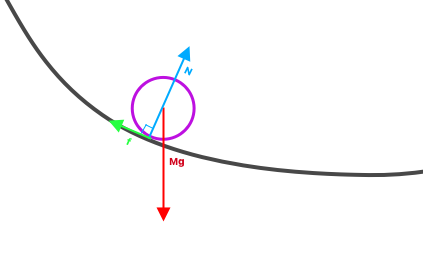

Figur 3.1

Figur 1 ovenfor illustrerer kreftene som virker på en rullende kule. normalkraften virker alltid vinkelrett på underlaget. Friksjonskraftens retning er definert av helningsvinkel $\beta$. Siden vi har definert positiv helningsvinkel som positiv, og positiv retning mot høyre virker friksjonskraften mot venstre. Dette gir også mening med tanke på at den statiske friksjonskraften på et punkt i en nedoverbakke vil virke i motsatt retning av helningen. Figur 2 illustrerer hvordan den statiske friksjonskraften vil virke i motsatt retning når helningsvinkelen skifter fra negativ til positiv.

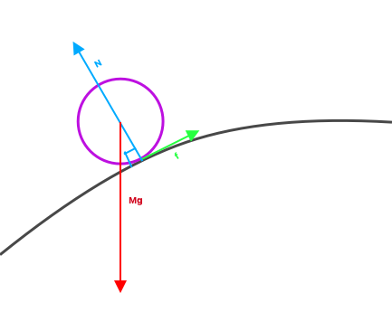

Figur 3.2

### Distanse som funksjon av tid

Når vi vet en kules fart i et hvert punkt $x$, kan vi enkelt finne dens fart i $x$-retningen ved å dekomponere. Kulens fart i x-retningen er gitt ved $v_x = v\cdot cos(\beta)$.

Dersom intervallene $\Delta x_n = x_n - x_{n-1}$ er konstante på f.eks. 1mm, kan vi finne den gjennomsnittlige farten i x-retning i hvert intervall $\Delta x_n$ gitt ved $ v_{\Delta x_n} = \frac{1}{2} \cdot (v_{\Delta x_{n-1}} + v_{\Delta x_{n}})$, for så å finne tiden kulen bruker på gjennom hvert intervall på 1mm. Dette er gitt ved:

$$\Delta t_n = \frac{2Δx_n}{v_{x,n-1} + v_{x,n}} \tag{3.j}$$

Med denne formelen kan man summere opp alle tidsdifferanser av $x$ og få den totale tiden brukt på hele distansen. en kan og lage en todimensjonal liste med tidsdifferanse per $x$-verdi. Med denne listen kan vi også hente ut en $x$-verdi per tidspunkt, og på denne måten har man en måte å finne distanse $x(t)$

### Fart som funksjon av tid

Dersom man har laget en liste med alle tidpunkter $t_n$ per distanse $x_n$, og vi fra før vet farten $v(x)$, kan man nå tilegne funksjonsverdien $v(x)$ til til den tilsvarende $t_n(x_n)$ og hente ut $v(t)$.

### Gjennomsnitt av målt sluttfart

Dersom vi gjør gjentatte målinger vil vi oppleve at resultatene avviker. Vi kan finne gjennomsnittet av målingene gjennomført, og bruke dette som et estimat for hva det mest sannsynlige resultatet av nye målinger er, også kalt forventningsverdien. Gjennomsnitter er gitt ved

$$ \bar{x} = \frac{1}{N}\sum_{i=1}^{N} x_i \tag{3.k}$$

### Standardavvik

Siden det finnes avvik fra gjennomsnittet ved de fleste målinger, er det forbundet en usikkerhet ved resultatene. Et mål på denne usikkerheten er standardavviket. Standardavviket er det gjennomsnittlige avviket fra forventningsverdien. Standardavviket $s$ er gitt ved:

$$σ = \sqrt{\frac{1}{N-1} \sum_{i=1}^n(x_i - \bar{x})^2} \tag{3.l}$$

### Standardfeil

Dersom vi øker antall målinger vil ikke standardavviket endre seg nevneverdig, men vi kan være mer sikker på at forventningsverdien og standardavviket stemmer. Derfor benytter vi verdien standardfeil, som reduseres ved økt antall målinger. Denne er gitt ved:

$$σ_\bar{x} = \frac{s}{\sqrt{N}} \tag{3.m}$$

# 4 Metode

## Numerikk

#### **Metoder for å initialisere numerikk-utregningen**

Hentet fra *cubicspline.ipynb* filen som var vedlagt oppgaven

```python
import matplotlib.pyplot as plt
import numpy as np
from scipy.interpolate import CubicSpline
from tabulate import tabulate

np.random.seed(3)

h = 0.200
xfast=np.asarray([0,h,2*h,3*h,4*h,5*h,6*h,7*h])

xmin = 0.000
xmax = 1.401
dx = 0.001

ymax = 300
# yfast: tabell med 8 heltall mellom 50 og 300 (mm); representerer
# høyden i de 8 festepunktene
yfast=np.asarray(np.random.randint(50, ymax, size=8))
#konverter fra m til mm
yfast =yfast/1000
# inttan: tabell med 7 verdier for (yfast[n+1]-yfast[n])/h (n=0..7); dvs
# banens stigningstall beregnet med utgangspunkt i de 8 festepunktene.
inttan = np.diff(yfast)/h
attempts=1
# while-løkken sjekker om en eller flere av de 3 betingelsene ovenfor
# ikke er tilfredsstilt; i så fall velges nye festepunkter inntil
# de 3 betingelsene er oppfylt
while (yfast[0] < yfast[1]*1.04 or
       yfast[0] < yfast[2]*1.08 or
       yfast[0] < yfast[3]*1.12 or
       yfast[0] < yfast[4]*1.16 or
       yfast[0] < yfast[5]*1.20 or
       yfast[0] < yfast[6]*1.24 or
       yfast[0] < yfast[7]*1.28 or
       yfast[0] < 0.250 or
       np.max(np.abs(inttan)) > 0.4 or
       inttan[0] > -0.2):
          yfast=np.asarray(np.random.randint(0, ymax, size=8))

          #konverter fra m til mm
          yfast =yfast/1000

          inttan = np.diff(yfast)/h
          attempts=attempts+1

# Omregning fra mm til m:
# xfast = xfast/1000
# yfast = yfast/1000

cs = CubicSpline(xfast, yfast, bc_type='natural')

xmin = 0.000
xmax = 1.401
dx = 0.001

x = np.arange(xmin, xmax, dx)

Nx = len(x)
y = cs(x)       #y=tabell med 1401 verdier for y(x)
dy = cs(x,1)    #dy=tabell med 1401 verdier for y'(x)
d2y = cs(x,2)   #d2y=tabell med 1401 verdier for y''(x)
```

```python
#Variable to change dimension and fontsize of all figures
figsize = (10,2)
fontsize = 12
```

#### **Kulebane**

Vi bestemte oss for en kulebane der de åtte festepunktene var:

```python
table = tabulate({'Festepunkt': [1,2,3,4,5,6,7,8],'X-verdi (m)': xfast, 'Y-verdi (m)':yfast}, tablefmt="fancy_grid", headers="keys")
print("Festepunkter til kulebanen")
print(table)
```

```
Festepunkter til kulebanen
╒══════════════╤═══════════════╤═══════════════╕
│   Festepunkt │   X-verdi (m) │   Y-verdi (m) │
╞══════════════╪═══════════════╪═══════════════╡
│            1 │           0   │         0.263 │
├──────────────┼───────────────┼───────────────┤
│            2 │           0.2 │         0.21  │
├──────────────┼───────────────┼───────────────┤
│            3 │           0.4 │         0.16  │
├──────────────┼───────────────┼───────────────┤
│            4 │           0.6 │         0.207 │
├──────────────┼───────────────┼───────────────┤
│            5 │           0.8 │         0.186 │
├──────────────┼───────────────┼───────────────┤
│            6 │           1   │         0.175 │
├──────────────┼───────────────┼───────────────┤
│            7 │           1.2 │         0.106 │
├──────────────┼───────────────┼───────────────┤
│            8 │           1.4 │         0.065 │
╘══════════════╧═══════════════╧═══════════════╛
```

Figur 4.1

Dette ga en kulebane som så slik ut:

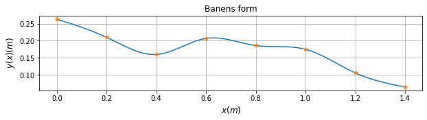

```python
baneform = plt.figure('y(x)',figsize)
plt.plot(x,y,xfast,yfast,'*')
plt.title('Banens form')
plt.xlabel('$x (m)$', fontsize=fontsize)
plt.ylabel('$y(x) (m)$',fontsize = fontsize)
plt.grid()
plt.show()
```

Figur 4.2

#### **Helningsvinkel**

Formelen for helningsvinkelen $\beta$ i hvert punkt $x$ er gitt ved: $\beta = \arctan{y'}$ (3.c). Dette ble diskutert i teoridelen.

Formelen ble brukt for å plotte helningsvinkelen til kulebanen i grader:

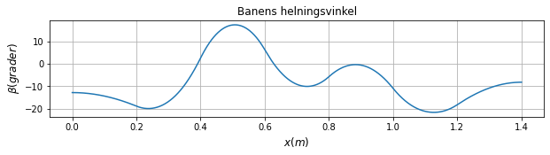

```python
beta=np.arctan(dy)*(180/np.pi)

helningsvinkel = plt.figure('beta',figsize)
plt.plot(x,beta)
plt.title('Banens helningsvinkel')
plt.xlabel('$x(m)$', fontsize=fontsize)
plt.ylabel(r'$\beta(grader)$', fontsize=fontsize)
plt.grid()
plt.show()
```

Figur 4.3

#### **Banens krumning**

Formelen brukt for å regne ut banens krumning er som beskrevet i teoridelen (3.d): $ k = \frac{y''}{(1+y'^2)^\frac{3}{2}}$

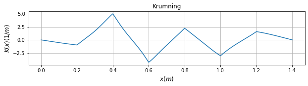

```python
k = d2y/((1+dy**2)**(3/2))

krumning = plt.figure('krumning',figsize)
plt.plot(x,k)
plt.title('Krumning')
plt.xlabel('$x(m)$', fontsize=fontsize)
plt.ylabel('$K(x) (1/m)$', fontsize=fontsize)
plt.grid()
plt.show()
```

Figur 4.4

#### **Kulas Hastighet**

I teoridelen ble det diskutert at kulas hastighet er gitt av formelen $v = \sqrt{\frac{2g(y_0-y)}{1+c}}$ (3.e), der $c$ er oppgitt som $c = \frac{2}{5}$

Denne formelen ble benyttet i utregningen og plottingen av kulas hastighet i kulebanen ved etthvert punkt i $x$-retning.

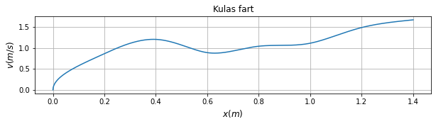

```python
fart_av_x = np.sqrt(((2*9.81*(yfast[0]-y))/(1+(2/5))))

fartgraf = plt.figure('fart',figsize)
plt.plot(x,fart_av_x)
plt.title('Kulas fart')
plt.xlabel('$x(m)$',fontsize=fontsize)
plt.ylabel('$v(m/s)$',fontsize=fontsize)
plt.grid()
plt.show()
```

Figur 4.5

#### **Normalkraften**

Utregning av normalkraften er diskutert i teoridelen og gitt ved formelen $N = m(g⋅cos{\beta} + \kappa v^2)$ (3.f)

Normalkraften til kula i etthvert punkt på kulebanen ble da plottet:

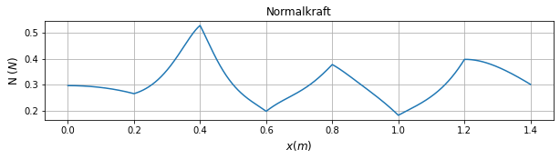

```python
M = 31 / 1000
g = 9.81
a_perpendicular = fart_av_x**2 * k

N = M*(g*np.cos(beta*(np.pi/180)) + a_perpendicular)

N_graf = plt.figure('Normalkraft',figsize)
plt.plot(x,N)
plt.title('Normalkraft')
plt.xlabel('$x(m)$',fontsize=fontsize)
plt.ylabel('N $(N)$',fontsize=fontsize)
plt.grid()
plt.show()
```

Figur 4.6

#### **Forholdet mellom friksjonskraft og normalkraft**

Teoridelen tok for seg at formelen for firksjonskraften er gitt ved $f = \frac{2Mg\sin{\beta}}{7}$ (3.h), og at formelen for normalkraften er $N = m(g⋅cos{\beta} + \kappa v^2)$ (3.f)

forholder mellom disse er $\frac{f}{N}$

Fra oppgaveteksten er vi gitt at $M = 31g$

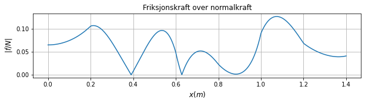

```python
f = abs((2*M*g*np.sin(beta*(np.pi/180)))/7)
forholdet = f / N

forholdet_graf = plt.figure('f/N',figsize)
plt.plot(x,forholdet)
plt.title('Friksjonskraft over normalkraft')
plt.xlabel('$x(m)$',fontsize=fontsize)
plt.ylabel('$|f/N|$',fontsize=fontsize)
plt.grid()
plt.show()
```

Figur 4.7

#### **Distanse som en funksjon av tid**

For å plotte horisontal distanse som funksjon av $t$ ble det regnet ut farten kula hadde i $x$-retning ved hver $x$-verdi, altså $v(x)$

```
v_x = fart_av_x * np.cos(beta * (np.pi/180))
```

Deretter ble det initialisert to lister med 0´ere:

```
d_t = np.zeros(len(v_x)-1)
t = np.zeros(len(v_x))
```

*d_t* listen blir deretter fyllt opp av endring i tid $Δt_n$ per $x$-verdi. Dette er gitt av formelen $\Delta t_n = \frac{2Δx_n}{v_{x,n-1} + v_{x,n}}$ (3.j) som ble diskutert i teoridelen

```
d_t[i] = (2*dx)/(v_x[i] + v_x[i+1])
```

```
t[i+1] = t[i]+d_t[i]
```

Grafen kunne dermed plottes med distanse $x$ langs $y$-aksen, og tilhørende $t_n$ langs $x$-aksen:

```python
v_x = fart_av_x * np.cos(beta * (np.pi/180))
d_t = np.zeros(len(v_x)-1)
t = np.zeros(len(v_x))

for i in range(len(d_t)):
    d_t[i] = (2*dx)/(v_x[i] + v_x[i+1])

for i in range(len(x)-1):
    t[i+1] = t[i]+d_t[i]
```

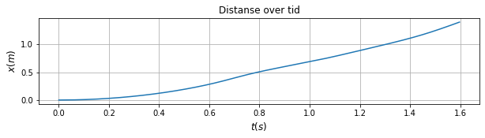

```python
pos_tid = plt.figure('x(t)',figsize)
plt.plot(t,x)
plt.title('Distanse over tid')
plt.xlabel('$t(s)$',fontsize=fontsize)
plt.ylabel('$x(m)$',fontsize=fontsize)
plt.grid()
plt.show()
```

Figur 4.8

#### **Fart som funksjon av tid**

Siden vi nå har laget en liste med alle tidpunkter $t_n$ per distanse $x_n$, og vi fra før vet farten $v(x)$, kan vi nå tilegne funksjonsverdien $v(x)$ til den tilsvarende $t_n(x_n)$ og dermed fremstille $v(t)$.

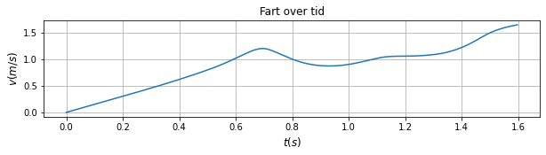

```python
fart_tid = plt.figure('v(t)',figsize)
plt.plot(t,v_x)
plt.title('Fart over tid')
plt.xlabel('$t(s)$',fontsize=fontsize)
plt.ylabel('$v(m/s)$',fontsize=fontsize)
plt.grid()
plt.show()
```

Figur 4.9

## Eksperiment

Etter at den numeriske delen av forsøket var gjennomført skulle sluttfarten til kula bestemmes eksperimentelt. Dette ble gjort ved hjelp av en fysisk kulebane og analyseprogrammet Tracker.

Det første som ble gjort var å sette opp kulebanen basert på de tilfeldige y-verdiene til festepunktene som ble generert i numerikk-delen. Banen ble satt slik at toppen av kulebanen samsvarte med koordinatene til festepunktene. Deretter ble kameraet festet til et stativ for å gi mest mulig like videoer, og det ble tatt 10 videoer av kula som rullet langs banen. Oppsettet for eksperimentet vises i figur 4.10.

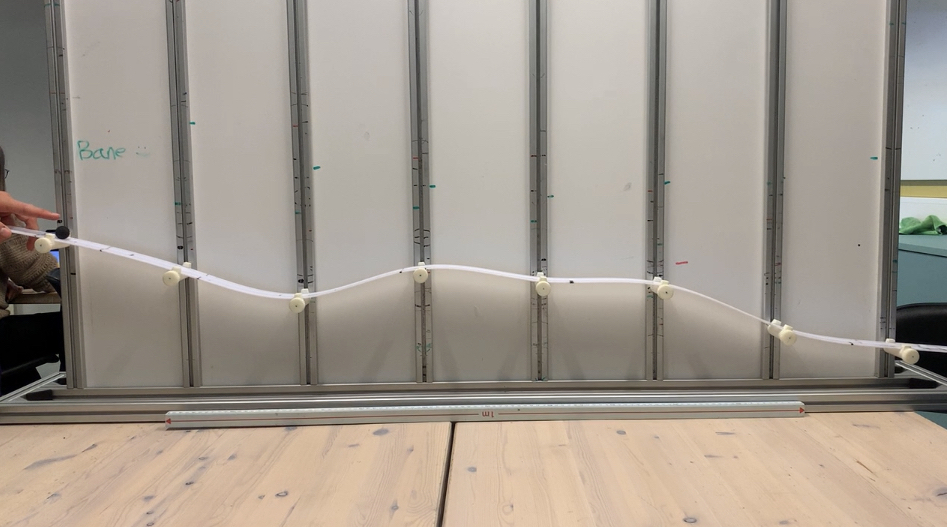

Figur 4.10

Hver av de 10 videoene ble analysert i Tracker. Programmet følger kulas posisjon under tidsutviklingen og på bakgrunn av dette blir sluttfart automatisk regnet ut. For at størrelsene i Tracker og eksperimentet skulle stemme overens måtte programmet kalibreres. Det ble brukt en kalibreringspinne på 1m, som vises på figur 4.10. Koordinatsystemet ble plassert nede i venstre hjørne på "tavlen" som banen sitter fast i slik at det stemte med koordinatene i numerikken-delen.

Sluttfartene ble manuelt hentet ut fra Tracker og samlet i listen "speed_tracking_data" nedenfor. Det ble også tatt ut data for en av videoene slik at vi kunne plotte og sammenligne den fysiske banen med den numeriske banen. Disse dataene er samlet i den todimensjonale listen "tracking_data" nedenfor, og hvert element er på formen [tid, x-koordinat, y-koordinat].

# 5 Resultater

```python
speed_tracking_data = [1.516, 1.501, 1.493, 1.545, 1.528, 1.491, 1.483, 1.483, 1.495, 1.428]
tracking_data = [
    [0.000,-5.529E-4,0.247],
    [0.033,-8.690E-4,0.249],
    [0.067,-6.833E-4,0.249],
    [0.100,1.568E-3,0.247],
    [0.133,4.566E-3,0.246],
    [0.167,8.937E-3,0.245],
    [0.200,1.585E-2,0.242],
    [0.234,2.331E-2,0.242],
    [0.267,3.418E-2,0.240],
    [0.300,4.453E-2,0.236],
    [0.334,5.897E-2,0.233],
    [0.367,7.372E-2,0.229],
    [0.400,9.206E-2,0.225],
    [0.434,0.110,0.220],
    [0.467,0.131,0.215],
    [0.500,0.154,0.208],
    [0.534,0.179,0.201],
    [0.567,0.206,0.193],
    [0.601,0.235,0.182],
    [0.634,0.267,0.173],
    [0.667,0.301,0.163],
    [0.701,0.339,0.156],
    [0.734,0.378,0.156],
    [0.767,0.415,0.157],
    [0.801,0.450,0.168],
    [0.834,0.483,0.177],
    [0.868,0.512,0.187],
    [0.901,0.540,0.194],
    [0.934,0.567,0.200],
    [0.968,0.593,0.201],
    [1.001,0.620,0.200],
    [1.034,0.647,0.196],
    [1.068,0.675,0.193],
    [1.101,0.703,0.188],
    [1.134,0.734,0.183],
    [1.168,0.765,0.182],
    [1.201,0.796,0.178],
    [1.235,0.828,0.178],
    [1.268,0.861,0.179],
    [1.301,0.892,0.179],
    [1.335,0.925,0.176],
    [1.368,0.958,0.175],
    [1.401,0.993,0.163],
    [1.435,1.029,0.151],
    [1.468,1.067,0.136],
    [1.502,1.107,0.118],
    [1.535,1.149,0.105],
    [1.568,1.196,8.884E-2],
    [1.602,1.244,8.148E-2],
    [1.635,1.294,7.775E-2],
    [1.668,1.343,7.288E-2],
  ]
```

Sammenligning av numerisk og målt bane.

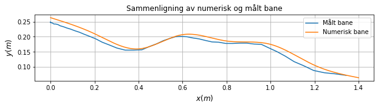

```python
x_track = np.zeros(len(tracking_data))
y_track = np.zeros(len(tracking_data))
for i in range(len(tracking_data)):
  x_track[i] = tracking_data[i][1]
  y_track[i] = tracking_data[i][2]

numersisk_track_bane = plt.figure('beta',figsize)
plt.plot(x_track,y_track, label = 'Målt bane')
plt.plot(x,y, label = 'Numerisk bane')
plt.title('Sammenligning av numerisk og målt bane')
plt.xlabel('$x (m)$', fontsize=fontsize)
plt.ylabel('$y (m)$',fontsize = fontsize)
plt.legend()
plt.grid()
plt.show()
```

Figur 5.1

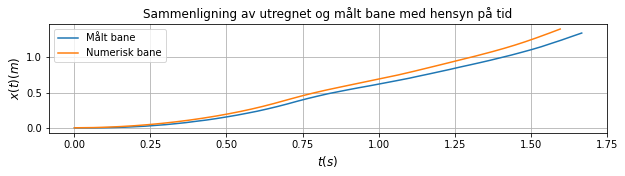

```python
x_t_track = np.zeros(len(tracking_data))
t_track = np.zeros(len(tracking_data))
for i in range(len(tracking_data)):
    t_track[i] = tracking_data[i][0]
    x_t_track[i] = tracking_data[i][1]

numerisk_track_xt = plt.figure('beta',figsize)
plt.plot(t_track,x_t_track, label = 'Målt bane')
plt.plot(t,x, label = 'Numerisk bane')
plt.title('Sammenligning av utregnet og målt bane med hensyn på tid')
plt.xlabel('$t(s)$', fontsize=fontsize)
plt.ylabel('$x(t)(m)$',fontsize = fontsize)
plt.legend()
plt.grid()
plt.show()
```

Figur 5.2

```python
forsok_liste = [1,2,3,4,5,6,7,8,9,10]
table_tracking_data = tabulate({'Forsøk nr': forsok_liste,'Sluttfart (m/s)': speed_tracking_data}, tablefmt="fancy_grid", headers="keys")
print('Målt sluttfart:\n')
print(table_tracking_data)
```

```
Målt sluttfart:

╒═════════════╤═══════════════════╕
│   Forsøk nr │   Sluttfart (m/s) │
╞═════════════╪═══════════════════╡
│           1 │             1.516 │
├─────────────┼───────────────────┤
│           2 │             1.501 │
├─────────────┼───────────────────┤
│           3 │             1.493 │
├─────────────┼───────────────────┤
│           4 │             1.545 │
├─────────────┼───────────────────┤
│           5 │             1.528 │
├─────────────┼───────────────────┤
│           6 │             1.491 │
├─────────────┼───────────────────┤
│           7 │             1.483 │
├─────────────┼───────────────────┤
│           8 │             1.483 │
├─────────────┼───────────────────┤
│           9 │             1.495 │
├─────────────┼───────────────────┤
│          10 │             1.428 │
╘═════════════╧═══════════════════╛
```

Figur 5.3

```python
energy_tracking_data = []

for speed in speed_tracking_data:
	energy_tracking_data.append(speed**2 * (1-(2/5))/2 * 31/1000)

gjennomsnitt_fart = sum(speed_tracking_data)/len(speed_tracking_data)
gjennomsnitt_energi = sum(energy_tracking_data)/len(energy_tracking_data)
```

Etter ti forskjellige runder med tilhørende målingger ble sluttfartene målt. I grafen sammenlignes målingene på banen med den numeriske utregnete banen.

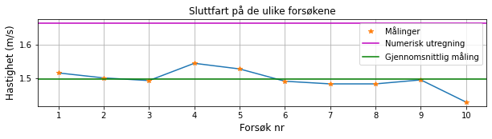

```python
endelig_fart = plt.figure('y(x)',figsize)
plt.plot(forsok_liste,speed_tracking_data)
plt.plot(forsok_liste,speed_tracking_data, '*', label = 'Målinger')
plt.axhline(y = fart_av_x[-1], color = 'm', label = 'Numerisk utregning')
plt.axhline(gjennomsnitt_fart, color = 'g', label = 'Gjennomsnittlig måling')
plt.title('Sluttfart på de ulike forsøkene')
plt.xlabel('Forsøk nr', fontsize=fontsize)
plt.ylabel('Hastighet (m/s)',fontsize = fontsize)
plt.xticks(forsok_liste)
plt.legend()
plt.grid()
plt.show()
```

Figur 5.4

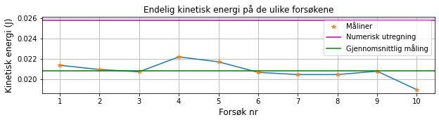

```python
endelig_energi = plt.figure('y(x)',figsize)
plt.plot(forsok_liste,energy_tracking_data)
plt.plot(forsok_liste,energy_tracking_data, '*', label = 'Måliner')
plt.axhline(y = fart_av_x[-1]**2*31/1000*(1-(2/5))/2, color = 'm', label = 'Numerisk utregning')
plt.axhline(gjennomsnitt_energi, color = 'g', label = 'Gjennomsnittlig måling')
plt.title('Endelig kinetisk energi på de ulike forsøkene')
plt.xlabel('Forsøk nr', fontsize=fontsize)
plt.ylabel('Kinetisk energi (J)',fontsize = fontsize)
plt.xticks(forsok_liste)
plt.legend()
plt.grid()
plt.show()
```

Figur 5.5

Gjennomsnittslig sluttfart fant vi med: $\bar{x} = \frac{1}{N} \sum_{i=1}^{N} x_i$ (3.k).

Dette kan sammenliknes med den numeriske utrengingen av sluttfart og kinetisk energi som ble plottet i metode-delen.

```python
numerisk_sluttfart = fart_av_x[-1]
numerisk_energi = fart_av_x[-1]**2 * 0.5 * 31/1000
print(f'Gjennomsnittlig slutthastighet:\t\t\t {gjennomsnitt_fart:.3f} m/s')
print(f'Den numerisk beregnede slutthastigheten:\t {numerisk_sluttfart:.3f} m/s')
print(f'Differanse:\t\t\t\t\t {abs(gjennomsnitt_fart - numerisk_sluttfart):.3f} m/s')
print(f'\nGjennomsnittlig kinetisk energi:\t\t {gjennomsnitt_energi:.3f} J')
print(f'Den numerisk beregnede kinentiske energien:\t {numerisk_energi:.3f} J')
print(f'Differanse:\t\t\t\t\t {abs(gjennomsnitt_energi - numerisk_energi):.3f} J')
```

```
Gjennomsnittlig slutthastighet:			 1.496 m/s
Den numerisk beregnede slutthastigheten:	 1.666 m/s
Differanse:					 0.169 m/s

Gjennomsnittlig kinetisk energi:		 0.021 J
Den numerisk beregnede kinentiske energien:	 0.043 J
Differanse:					 0.022 J
```

Ved hjelp av gjennomsnittet kan standardavviket finnes ved: $ s = \sqrt{\frac{1}{N-1} \sum_{i=1}^{N}(x_i - \bar{x})^2 } $ (3.l)

```python
summ_fart = 0
for data in speed_tracking_data:
  summ_fart += (data - gjennomsnitt_fart)**2

summ_energi = 0
for data in energy_tracking_data:
  summ_energi += (data - gjennomsnitt_energi)**2

standardavvik_fart = np.sqrt(1/(len(speed_tracking_data)-1) * summ_fart)
standardavvik_energi = np.sqrt(1/(len(energy_tracking_data)-1) * summ_energi)
print(f'Standardavvik for listen med sluttfarter er:\t {standardavvik_fart:.3e}')
print(f'Standardavvik for listen med kinetisk energi er: {standardavvik_energi:.3e}')
```

```
Standardavvik for listen med sluttfarter er:	 3.135e-02
Standardavvik for listen med kinetisk energi er: 8.671e-04
```

Etter å ha funnet standardavviket, finner vi standardfeilen: $ \bar{s} = \frac{s}{\sqrt{N}} $ (3.m)

```python
standardfeil_fart = standardavvik_fart / np.sqrt(len(speed_tracking_data))
standardfeil_energi = standardavvik_energi / np.sqrt(len(energy_tracking_data))
print(f'Standardfeilen for listen med sluttfarter er:\t  {standardfeil_fart:.3e} m/s')
print(f'Standardfeilen for listen med kinetisk energi er: {standardfeil_energi:.3e} J')
```

```
Standardfeilen for listen med sluttfarter er:	  9.914e-03 m/s
Standardfeilen for listen med kinetisk energi er: 2.742e-04 J
```

```python
print(f'Sluttfart: \t\t{gjennomsnitt_fart:.3f} ± {standardfeil_fart:.3e} m/s')
print(f'Endelig kinetisk energi:{gjennomsnitt_energi:.3f} ± {standardfeil_energi:.3e} J')
```

```
Sluttfart: 		1.496 ± 9.914e-03 m/s
Endelig kinetisk energi:0.021 ± 2.742e-04 J
```

# 6 Diskusjon

I resultatdelen ble det vist at verdiene for både numerikken og eksperimentet skilte seg. Gjennomsnittet for kulas observerte sluttfart og kinetiske energi regnet ut. Disse observerte verdiene skiller seg fra de numerisk utregnede. Vi ser at den numeriske verdien ble regnet ut til $1.666\, m/s$, og den observerte verdien målt til $1.496 ± 9.914\cdot 10^{-3} \,m/s$. Dette ga en gjennomsnittelig differanse på $0.169\, m/s$, med den numeriske verdien høyere enn den målte.

Mulige feilkilder til disse differansene blir diskutert i det følgende.

#### Baneform

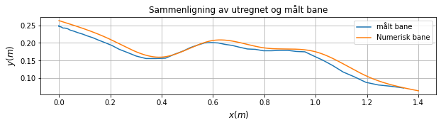

```python
plt.figure('beta',figsize)
plt.plot(x_track,y_track, label = 'målt bane')
plt.plot(x,y, label = 'Numerisk bane')
plt.title('Sammenligning av utregnet og målt bane')
plt.xlabel('$x(m)$', fontsize=fontsize)
plt.ylabel('$y(m)$',fontsize = fontsize)
plt.legend()
plt.grid()
plt.show()
```

Figur 6.1

Figur 6.1 viser den numerisk genererte baneformen og banen basert på vår input i tracker-programmet. Dataen vi la inn i tracker-programmet er basert på en video av banen og kulas posisjoner. Høyden på banen er regnet ut med et utgangspunkt i en målestokk som referansepunkt. Det vil være systematiske feil ved vinkel på kameraopsettet, lengde/plassering av målestokken, og plassering av målepunkter i programvaren.

Fra figuren over kan en se at den faktiske banen har en lavere starthøyde og en høyere slutthøyde enn den trackeren har benyttet i sine utregninger. Dette vil føre til avvik i både sluttfart og kinetisk energi.

#### Ulik sluttfart

Den observerte sluttfarten var lavere enn den numerisk utregnede. En mulig grunn til dette kan være at den numeriske utregningen ikke tok hensyn til luftmotstanden. Dette vil naturligvis medføre at den numeriske verdien er høyere en den reelt målte verdien.

En annen grunn kan være at kula ikke har en perfekt uniform massefordeling. Formelen brukt i den numeriske utregningen tar utgangspunkt i en perfekt uniform massefordeling, med massesenter i sentrum. I vårt eksperiment er det naturlig å anta at kula ikke er perfekt uniformt fordelt rundt sentrum, som vil gjøre at kula ikke ruller mer ujevnt.

Den ulike sluttfarten kan også begrunnes med ujevn friksjon mellom kula og underlaget. Det må være naturlig å anta at kula ikke er en perfekt kule, men at den er litt ujevn i formen. Dette ville medført at kula ruller saktere enn en perfekt kule.

Enda en grunn til ulik sluttfart er at startfarten er ulik. En menneskelig feil ved startingen av kula vil kunne gi kula en høyere startfart. Dette ville resultert i en høyere sluttfart enn den numerisk utregnede.

En siste feilkilde kan være ulike sluttpunkter. Grafene i resultatdelen viser at tracker-softwaren har ulik sluttpunkt enn den bergent numerisk. Dette vil naturligvis ha en påvirkning på kulefarten.

#### Ulik kinetisk energi

Som beskrevet i resultatdelen var også den numerisk utrgnede kinetiske energien større enn den målte i eksperimentet. En grunn til dette kan være pga. de unøyaktige ukonsistente sluttfartene fra forsøket. En unøyaktig ukonsistent sluttfart vil direkte påvirke formelen for kinetisk energi, beskrevet i teoridelen. Det vil si at feilkildene for sluttfarten diskutert i avsnittet ovenfor også vil påvirke den kinetiske energien.

# 7 Konklusjon

# 8 Referanser

- Augbert, K. E. (2022, May 6). Krumning. Store Norske Leksikon. https://snl.no/krumning
- Grøn, Ø. (2021a, July 9). Kinetisk energi. Store Norske Leksikon. https://snl.no/kinetisk_energi
- Grøn, Ø. (2021b, September 2). Newtons lover. Store Norske Leksikon. https://snl.no/Newtons_lover
- J. A. Støvneng. (2021). TFY41xx Fysikk: Labprosjekt Vår 2021. NTNU. https://home.phys.ntnu.no/brukdef/undervisning/fyslab/files/labligninger.pdf